# Fall 2021 - Math 421 - Midterm

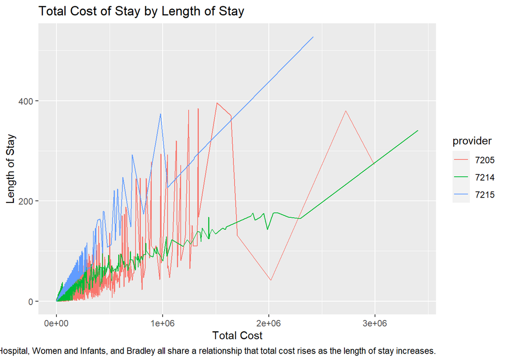

```r
df2 %>%
  filter(provider=='7215'|provider=='7214'|provider=='7205') %>%
  ggplot()+
  geom_line(mapping = aes(x = tot, y = los, color = provider))+
  labs(x='Total Cost',
       y = 'Length of Stay',
       title = 'Total Cost of Stay by Length of Stay',
       caption = 'Rhode Island Hospital, Women and Infants, and Bradley all share a relationship that total cost rises as the length of stay increases.')
```

Plot 9

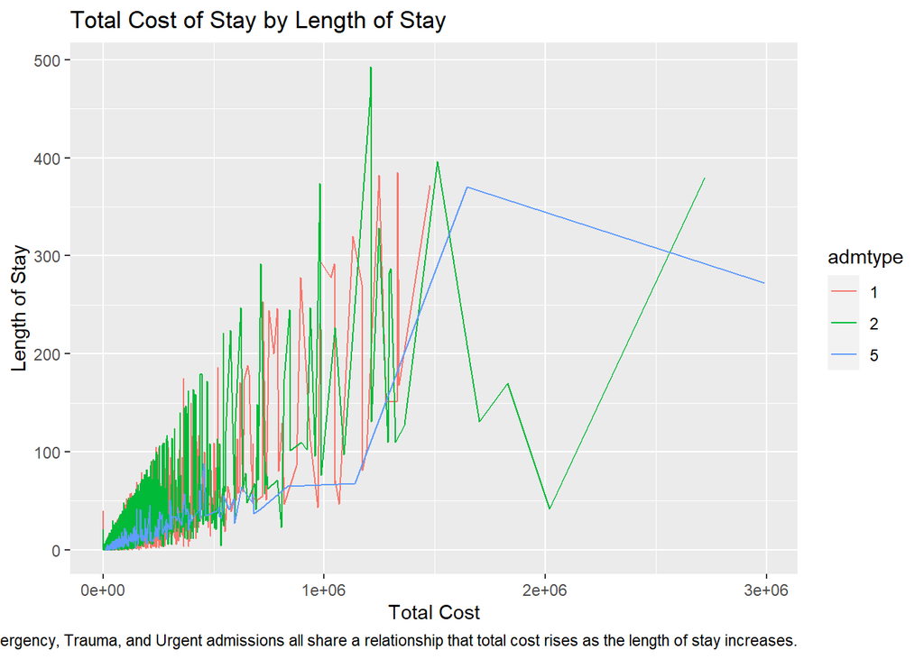

```r
df2 %>%
  filter(admtype=='1'|admtype=='5'|admtype=='2') %>%
  ggplot()+
  geom_line(mapping = aes(x = tot, y = los, color = admtype))+
  labs(x='Total Cost',
       y = 'Length of Stay',
       title = 'Total Cost of Stay by Length of Stay',
       caption = 'Emergency, Trauma, and Urgent admissions all share a relationship that total cost rises as the length of stay increases.')
```

Plot 10

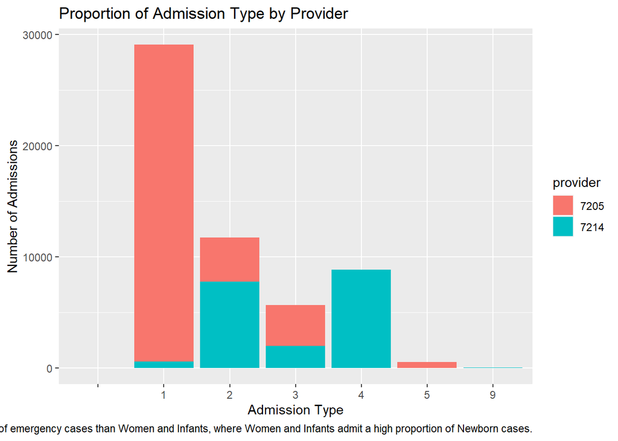

```r
df2 %>%
  filter(provider=='7205'|provider=='7214') %>%
  ggplot()+
  geom_bar(mapping = aes(x = admtype, fill = provider))+
    labs(x='Admission Type',
       y = 'Number of Admissions',
       title = 'Proportion of Admission Type by Provider',
       caption = 'Rhode Island Hospital admits a significantly higher proportion of emergency cases than Women and Infants, where Women and Infants admit a high proportion of Newborn cases.')
```

2. Make an animation plot.

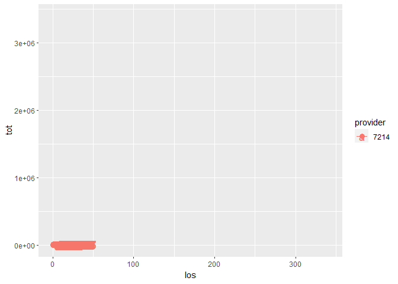

```r
library(tidyverse)
library(gganimate)
p3 <- df2 %>%
    filter(provider %in% c('7214')) %>%
    ggplot(aes(y=tot,
               x=los,
               color=provider))+
    geom_line()+
    geom_point(size=3)+
    geom_text(aes(label = tot),
              hjust = -.1, size=5) +
    transition_reveal(tot)
animate(p3)
```

3. Write a paragraph to summarize the section and give your comments on the results.

## III. Predictive Models

Continue with the data from part I. Make sure you do not have any missing values in the data. Use the follows as the target and input variables:

*Target Variable*: Create the target variable taking value of

- `low` if the total charge of a patient (`tot`) is smaller than the median of the total charge, and
- `high` otherwise.

*Input Variables*:

- “age”,“sex”,“raceethn”,“provider”,“moa”,“mod”,“admtype”,“campus”, ‘los’
1. Use `filter` function to filter out rows where `raceethn==''` or `admtype==''`. Make sure all the categorical variables are factor, numeric variables are numeric. Set Training : Testing Split = 10 : 90

```r
library(tidyverse)
df12 <-  select(df2,"age", "raceethn", "sex", "provider", "moa", "mod", "admtype", "campus", "los")

df12$sex <- factor(df12$sex)
df12$raceethn <- factor(df12$raceethn)
df12$provider <- factor(df12$provider)
df12$admtype <- factor(df12$admtype)
df12$campus <- factor(df12$campus)



df12$target <- cut(df2$tot,
                      breaks = c(-Inf, 218854,Inf),
                      labels=c('low','high'), na.rm=TRUE)

library(caret)
set.seed(2020)
splitIndex <- createDataPartition(df2$tot, p = .10,
                                  list = FALSE)
df12_train <- df12[ splitIndex, na.rm=TRUE]
df12_test <- df12[-splitIndex, na.rm=TRUE]
```

2. Train a decision tree using `rpart`. Plot the decision tree. Plot the variable importance ranked by the tree.

[figure not shown]

```r
library(rpart)
tree_model <- rpart(target ~ ., data = df12_train,
                 control = rpart.control(maxdepth = 3))
library(rattle)
fancyRpartPlot(tree_model)
```

```r
tree_model$variable.importance
```

```
##       los  provider    campus       age   admtype       moa  raceethn
## 99.797175 16.077746  3.897635  3.188487  2.923226  1.461613  1.107039
```

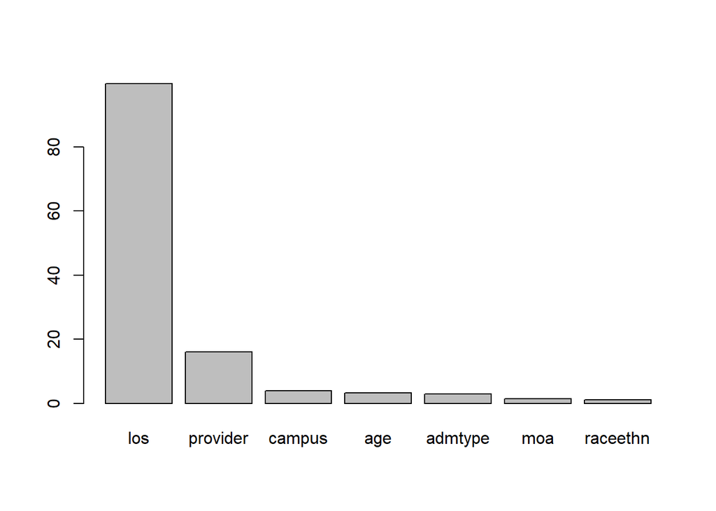

```r
barplot(tree_model$variable.importance)
```

3. Using caret for this question. Set `Training Control` to be: Use Cross-Validation of 5 folds across all models. Train & tune at least 3 different models (i.e. three different values for `method=` in the train function of caret). Plot the hyper-parameter tuning plots for each model.

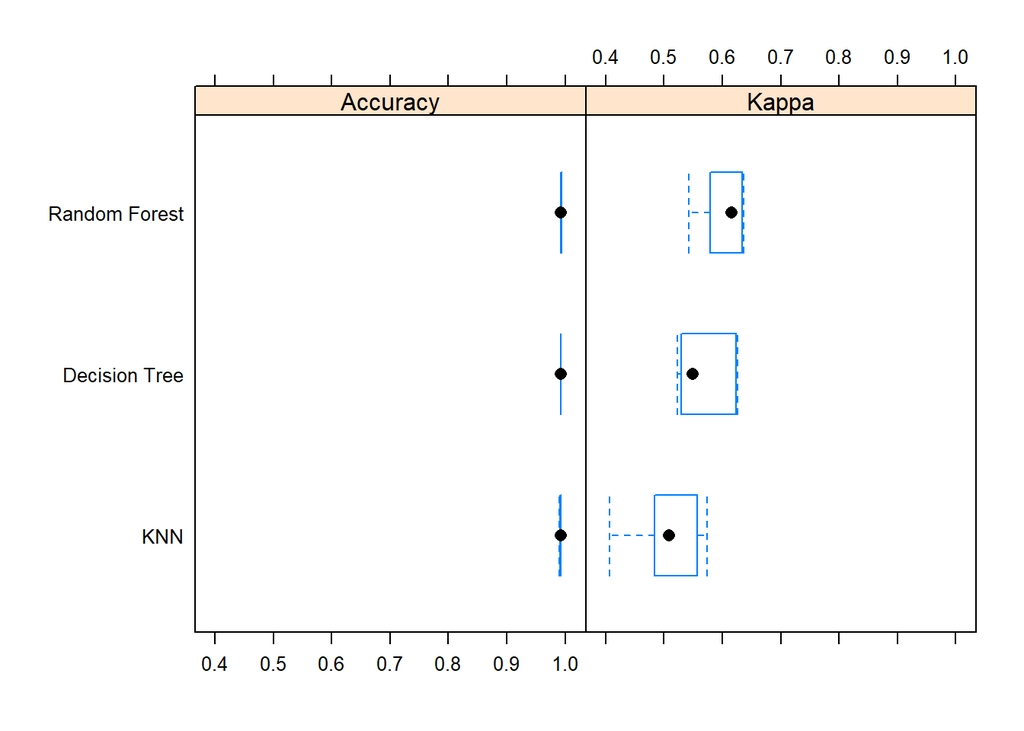

```r
library(tidyverse)
library(rpart)
library(caret)


trControl = trainControl(method = "cv",
                         number = 5)
forest_ranger <- train(target~., data=df12_train,
                    method = "ranger",
                    trControl = trControl)
tree <- train(target~., data=df12_train,
                                method = "rpart2",
                                trControl = trControl)
knn <- train(target~., data=df12_train,
                                method = "knn",
                                trControl = trControl)

results <- resamples(list('Decision Tree' = tree,
                          'Random Forest' = forest_ranger,
                          'KNN'= knn))
bwplot(results)
```

4. Plot the comparison of the models in 3.

Model is plotted above in Question 3.

5. What is your final selection for the model? Test the accuracy of your final model on the test data.

6. Create another `target` variable (binary), decide the input variables and redo 1 to 5.
7. Write a paragraph to summarize the section and give your comments on the results.

I ran across many issues and challenged within this section of the project. For example, I struggled with removing missing values. To solve this issue, I created a new dataset, “df12”, with other the necessary input variables that I was positive did not have any missing values. It took me a while to think of this solution, but it worked quickly once I did so. When creating tree model and graphing it, I chose to analyze the length of stay in relation to different providers and the total costs of each patient’s visit. This tree model told me that Length of Stays greater then 36 days have a stronger relationship between total costs and which provider may charge higher rates. When I created three separate models to test and compare, I used Decision Tree, Random Forest, and KNN methods to evaluate. I believe that the Random Forest method is the best method to use for this particular dataset because the accuracy part of the evaluation is the most similar to the kappa section. The boxes look more alike, so I chose Random Forest to be the best option of all three methods I tested. ——-